# GDP Postgres sql

- build a well known data vis, that helps to confirm if you’re right
- tons of econ teams will be talking about this 4 times per year, if something creative strikes you, you have the foundation to start with this well known chart, and expand
- go to the source; good practice; why not?, why depend or wait for FRED?
- you’ll find other cool stuff from taht provider, a primer on GDP, the components
- it’s, again, good practice for when FRED or quandl or tidyquant or quantmod hasn’t wrapped it for you, like if you’re trying to pull together different internal data to create a unique data set. you don’t want that to be the first time you’ve wrestled with data import and wrangling
- can use with other data sets; see employment data post
- plunk it into a sql database for safekeeping

### Download gdp level excel from BEA

```r
gdp_change_from_postrgres %>%
mutate(col_blue =
           if_else(percent_change > 0,
                  percent_change, as.numeric(NA)),
         col_red =
           if_else(percent_change < 0,
                  percent_change, as.numeric(NA))) %>%
  ggplot(aes(x = quarter)) +
  geom_col(aes(y = col_red),
               alpha = .85,
               fill = "pink",
               color = "pink") +
  geom_col(aes(y = col_blue),
               alpha = .85,
               fill = "cornflowerblue",
               color = "cornflowerblue") +
  ylab("Monthly Change (thousands)") +
  scale_y_continuous(labels = scales::percent,
                     breaks = scales::pretty_breaks(n = 10)) +
  #scale_x_date(breaks = scales::pretty_breaks(n = 10)) +
  labs(title = "Quarterly GDP Growth",
       subtitle = "since 1998",
       caption = "more here: www.bea.gov/newsreleases/national/gdp/gdpnewsrelease.htm") +
  theme_minimal() +
  theme(axis.text.x = element_text(angle = 90, hjust = 1),
        plot.title = element_text(hjust = 0.5),
        plot.subtitle = element_text(hjust = 0.5),
        plot.caption=element_text(hjust=0))
```

```r
gdp_change_hc <-
  gdp_change_from_postrgres %>%
  mutate(coloract = ifelse(percent_change > 0, "#6495ed", "#ffe6ea"),
         percent_change = formattable::percent(round(percent_change, 2)))


highchart() %>%
  hc_title(text = paste("GDP quarterly growth since",
                        lubridate::month(first(gdp_change_hc$quarter),
                                         label = TRUE,
                                         abbr = FALSE),
                         lubridate::year(first(gdp_change_hc$quarter)),
                        sep = " ")) %>%
  hc_add_series(gdp_change_hc,
                "column",
                pointWidth = 5,
                hcaes(x = quarter,
                      y = percent_change,
                      color = coloract),
                name = "gdp quarterly change") %>%
  hc_xAxis(type = "datetime") %>%
  hc_exporting(enabled = TRUE) %>%
  hc_yAxis(labels = list(format = "{value}%")) %>%
  hc_tooltip(pointFormat = '{point.y:.2f}%')
```

[interactive chart not shown]

```r
NA
```

### Calculate quarterly growth

```r
gdp_quarterly_growth <-
  gdp_quarterly_from_postrgres %>%
  mutate(percent_change_current =
           ((1+ (GDP_current_dollars-lag(GDP_current_dollars, 1))/
               lag(GDP_current_dollars, 1))^4) - 1,
         percent_change_2012 =
           ((1+ (GDP_2012_dollars-lag(GDP_2012_dollars, 1))/
               lag(GDP_2012_dollars, 1))^4) - 1,
         quarter = yq(quarter)) %>%
  filter(quarter > "1997-10-01") %>%
  na.omit()
```

### Vis with ggplot

```r
gdp_quarterly_growth %>%
mutate(col_blue =
           if_else(percent_change_2012 > 0,
                  percent_change_2012, as.numeric(NA)),
         col_red =
           if_else(percent_change_2012 < 0,
                  percent_change_2012, as.numeric(NA))) %>%
  ggplot(aes(x = quarter)) +
  geom_col(aes(y = col_red),
               alpha = .85,
               fill = "pink",
               color = "pink") +
  geom_col(aes(y = col_blue),
               alpha = .85,
               fill = "cornflowerblue",
               color = "cornflowerblue") +
  ylab("Monthly Change (thousands)") +
  scale_y_continuous(labels = scales::percent,
                     breaks = scales::pretty_breaks(n = 10)) +
  scale_x_date(breaks = scales::pretty_breaks(n = 10)) +
  labs(title = "Quarterly GDP Growth",
       subtitle = "since 1998",
       caption = "more here: www.bea.gov/newsreleases/national/gdp/gdpnewsrelease.htm") +
  theme_minimal() +
  theme(axis.text.x = element_text(angle = 90, hjust = 1),
        plot.title = element_text(hjust = 0.5),
        plot.subtitle = element_text(hjust = 0.5),
        plot.caption=element_text(hjust=0))
```

### Visualize GDP growth with highcharter

```r
gdp_quarterly_growth_hc <-
  gdp_quarterly_growth %>%
  mutate(coloract = ifelse(percent_change_2012 > 0, "#6495ed", "#ffe6ea"),
         percent_change_2012 = formattable::percent(round(percent_change_2012 * 100, 2)))


highchart() %>%
  hc_title(text = paste("GDP quarterly growth since",
                        lubridate::month(first(gdp_quarterly_growth_hc$quarter),
                                         label = TRUE,
                                         abbr = FALSE),
                         lubridate::year(first(gdp_quarterly_growth_hc$quarter)),
                        sep = " ")) %>%
  hc_add_series(gdp_quarterly_growth_hc,
                "column",
                pointWidth = 5,
                hcaes(x = quarter,
                      y = percent_change_2012,
                      color = coloract),
                name = "gdp quarterly change") %>%
  hc_xAxis(type = "datetime") %>%
  hc_exporting(enabled = TRUE) %>%
  hc_yAxis(labels = list(format = "{value}%")) %>%
  hc_tooltip(pointFormat = "{point.y:.1f}%")
```

### GDP components

[output not shown]

Let’s download the excel file from the BEA website and specify our sheet. We want the sheet which contains the quarterly change of the GDP components. That is Table 1.1.2-Q, which turns out to be called `sheet = "T10102-Q"` in the excel file.

```r
url <- "https://www.bea.gov/national/Release/XLS/Survey/Section1All_xls.xlsx"
destfile <- "Section1All_xls.xlsx"
curl::curl_download(url, destfile)
gdp_component_change_quarterly <-
  read_excel("Section1All_xls.xlsx",
             sheet = "T10102-Q",
             col_types = c("skip",
        "text", "skip", "numeric", "numeric",
        "numeric", "numeric", "numeric",
        "numeric", "numeric", "numeric",
        "numeric", "numeric", "numeric",
        "numeric", "numeric", "numeric",
        "numeric", "numeric", "numeric",
        "numeric", "numeric", "numeric",
        "numeric", "numeric", "numeric",
        "numeric", "numeric", "numeric",
        "numeric", "numeric", "numeric",
        "numeric", "numeric", "numeric",
        "numeric", "numeric", "numeric",
        "numeric", "numeric", "numeric",
        "numeric", "numeric", "numeric",
        "numeric", "numeric", "numeric",
        "numeric", "numeric", "numeric",
        "numeric", "numeric", "numeric",
        "numeric", "numeric", "numeric",
        "numeric", "numeric", "numeric",
        "numeric", "numeric", "numeric",
        "numeric", "numeric", "numeric",
        "numeric", "numeric", "numeric",
        "numeric", "numeric", "numeric",
        "numeric", "numeric", "numeric",
        "numeric", "numeric", "numeric",
        "numeric", "numeric", "numeric",
        "numeric", "numeric", "numeric",
        "numeric", "numeric", "numeric",
        "numeric", "numeric", "numeric",
        "numeric", "numeric", "numeric",
        "numeric", "numeric", "numeric",
        "numeric", "numeric", "numeric",
        "numeric", "numeric", "numeric",
        "numeric", "numeric", "numeric",
        "numeric", "numeric", "numeric",
        "numeric", "numeric", "numeric",
        "numeric", "numeric", "numeric",
        "numeric", "numeric", "numeric",
        "numeric", "numeric", "numeric",
        "numeric", "numeric", "numeric",
        "numeric", "numeric", "numeric",
        "numeric", "numeric", "numeric",
        "numeric", "numeric", "numeric",
        "numeric", "numeric", "numeric",
        "numeric", "numeric", "numeric",
        "numeric", "numeric", "numeric",
        "numeric", "numeric", "numeric",
        "numeric", "numeric", "numeric",
        "numeric", "numeric", "numeric",
        "numeric", "numeric", "numeric",
        "numeric", "numeric", "numeric",
        "numeric", "numeric", "numeric",
        "numeric", "numeric", "numeric",
        "numeric", "numeric", "numeric",
        "numeric", "numeric", "numeric",
        "numeric", "numeric", "numeric",
        "numeric", "numeric", "numeric",
        "numeric", "numeric", "numeric",
        "numeric", "numeric", "numeric",
        "numeric", "numeric", "numeric",
        "numeric", "numeric", "numeric",
        "numeric", "numeric", "numeric",
        "numeric", "numeric", "numeric",
        "numeric", "numeric", "numeric",
        "numeric", "numeric", "numeric",
        "numeric", "numeric", "numeric",
        "numeric", "numeric", "numeric",
        "numeric", "numeric", "numeric",
        "numeric", "numeric", "numeric",
        "numeric", "numeric", "numeric",
        "numeric", "numeric", "numeric",
        "numeric", "numeric", "numeric",
        "numeric", "numeric", "numeric",
        "numeric", "numeric", "numeric",
        "numeric", "numeric", "numeric",
        "numeric", "numeric", "numeric",
        "numeric", "numeric", "numeric",
        "numeric", "numeric", "numeric",
        "numeric", "numeric", "numeric",
        "numeric", "numeric", "numeric",
        "numeric", "numeric", "numeric",
        "numeric", "numeric", "numeric",
        "numeric", "numeric", "numeric",
        "numeric", "numeric", "numeric",
        "numeric", "numeric", "numeric",
        "numeric", "numeric", "numeric",
        "numeric", "numeric", "numeric",
        "numeric", "numeric", "numeric",
        "numeric", "numeric", "numeric",
        "numeric", "numeric", "numeric",
        "numeric", "numeric", "numeric",
        "numeric", "numeric", "numeric",
        "numeric", "numeric", "numeric",
        "numeric", "numeric", "numeric",
        "numeric", "numeric", "numeric",
        "numeric"), skip = 6) %>%
  slice(-1) %>%
  slice(-2)
```

### Wrangle and transform

The data arrived with the variables as rows and each column as a quarter - that’s why it is 286 variables wide. It’s not an uncommon way for economic data to be organized but it’s definitely not tidy. We want to reorganize the data so that there is a column for the date and for each economic variable that contributes to GDP.

```r
 gdp_comp_change_wrangled <-
  # transpose the data
  t(gdp_component_change_quarterly) %>%
  # make row 1 into column names
  `colnames<-`(.[1,]) %>%
  # conver the rownames into a column
  # and ponder why we would ever want rownames instead of a column?
  as_tibble(rownames = "quarter") %>%
  # delete the first row
  slice(-1) %>%
  # convert the quarter column into a date format
  mutate(quarter = as.yearqtr(quarter)) %>%
  # convert to numberics
  mutate_if(is.character, funs(as.numeric(.)))


DBI::dbRemoveTable(con, "gdp_comp_change_wrangled")
DBI::dbWriteTable(con, "gdp_comp_change_wrangled", gdp_comp_change_wrangled)
```

```r
  gdp_comp_change_transposed %>%
  dplyr::select(quarter,
                GDP = `Gross domestic product`,
                consumption = `Personal consumption expenditures`,
                investment =  `Gross private domestic investment`,
                net_exports = `Net exports of goods and services`,
                government = `Government consumption expenditures and gross investment`) %>%
  # test for consistency
  mutate(gdp_change = rowSums(select_(., -1, -2))) %>%
  dplyr::select(quarter, gdp_change, everything())
```

| quarter | gdp_change | GDP | consumption | investment | net_exports | government |
| --- | --- | --- | --- | --- | --- | --- |
| 1947 Q2 | -1.060000e+00 | -1.0 | 4.30 | -4.71 | -0.68 | 0.03 |
| 1947 Q3 | -8.200000e-01 | -0.8 | 0.94 | -1.83 | -0.16 | 0.23 |
| 1947 Q4 | 6.410000e+00 | 6.4 | 0.25 | 10.69 | -4.23 | -0.30 |
| 1948 Q1 | 6.160000e+00 | 6.2 | 1.51 | 6.28 | -2.98 | 1.35 |
| 1948 Q2 | 6.780000e+00 | 6.8 | 3.12 | 4.32 | -3.00 | 2.34 |
| 1948 Q3 | 2.320000e+00 | 2.3 | 0.37 | 0.92 | -0.32 | 1.35 |
| 1948 Q4 | 4.500000e-01 | 0.4 | 1.83 | -3.04 | -0.60 | 2.26 |
| 1949 Q1 | -5.400000e+00 | -5.4 | 0.17 | -9.91 | 2.85 | 1.49 |
| 1949 Q2 | -1.350000e+00 | -1.4 | 3.57 | -7.86 | 0.02 | 2.92 |
| 1949 Q3 | 4.190000e+00 | 4.2 | 0.15 | 4.98 | -1.32 | 0.38 |

[output cut: 275 more lines]

Let’s grab just the top level components first. If you forgot to bring your Macro text book, thats personal consumption/expenditure, net exports and good ol’government.

```r
gdp_top_level_components <-
  gdp_comp_change_transposed %>%
  dplyr::select(quarter,
                GDP = `Gross domestic product`,
                consumption = `Personal consumption expenditures`,
                investment =  `Gross private domestic investment`,
                net_exports = `Net exports of goods and services`,
                government = `Government consumption expenditures and gross investment`) %>%
  gather(account, quarterly_change, -quarter) %>%
  group_by(account)

gdp_top_level_components %>% slice(1:2
                                   )
```

| quarter | account | quarterly_change |
| --- | --- | --- |
| 1947 Q2 | consumption | 4.30 |
| 1947 Q3 | consumption | 0.94 |
| 1947 Q2 | GDP | -1.00 |
| 1947 Q3 | GDP | -0.80 |
| 1947 Q2 | government | 0.03 |
| 1947 Q3 | government | 0.23 |
| 1947 Q2 | investment | -4.71 |
| 1947 Q3 | investment | -1.83 |
| 1947 Q2 | net_exports | -0.68 |
| 1947 Q3 | net_exports | -0.16 |

Alright, we have the quarterly change to total GDP, and to each of its consituents. Let’s visualize just the most recent quarter.

```r
gdp_top_level_components %>%
  filter(quarter == last(quarter)) %>%
   mutate(col_blue =
           if_else(quarterly_change > 0,
                  quarterly_change, as.numeric(NA)),
         col_red =
           if_else(quarterly_change < 0,
                  quarterly_change, as.numeric(NA))) %>%
  ggplot(aes(x = reorder(account, quarterly_change))) +
  geom_col(aes(y = col_red),
               alpha = .85,
               fill = "pink",
               color = "pink",
               width = .5) +
  geom_col(aes(y = col_blue),
               alpha = .85,
               fill = "cornflowerblue",
               color = "cornflowerblue",
               width = .5) +
  labs(title = paste(last(gdp_top_level_components$quarter),
                     "GDP Change",
                     sep = " "),
       subtitle = "by account, and total",
       x = "account",
       y = "change last quarter") +
  theme_minimal() +
  theme(axis.text.x = element_text(angle = 90, hjust = 1),
        plot.title = element_text(hjust = 0.5),
        plot.subtitle = element_text(hjust = 0.5)) +
  scale_y_continuous(breaks = scales::pretty_breaks(n = 10))
```

```r
gdp_top_level_hc <-
  gdp_top_level_components  %>%
  filter(quarter == (last(quarter))) %>%
  arrange(quarterly_change) %>%
  mutate(coloract = if_else(quarterly_change > 0, "#6495ed", "#ffe6ea"))



highchart() %>%
  hc_add_series(gdp_top_level_hc,
                "column",
                pointWidth = 20,
                hcaes(x = account,
                      y = quarterly_change,
                      color = coloract),
                showInLegend = FALSE) %>%
  hc_title(text = paste(gdp_top_level_hc$quarter,
                        "GDP Change",
                        sep = " ")) %>%
  hc_xAxis(categories = gdp_top_level_hc$account) %>%
  hc_xAxis(title = list(text = "account")) %>%
  hc_yAxis(title = list(text = "Monthly Change (percent)")) %>%
  hc_exporting(enabled = TRUE) %>%
  hc_yAxis(labels = list(format = "{value}%")) %>%
  hc_tooltip(pointFormat = "{point.y:.1f}%")
```

[interactive chart not shown]

```r
NA
```

### Break down to second level and confirm

Alright, let’s go to the second level components of GDP and identify what contributed to the top level changes that we see above.

```r
  gdp_comp_change_transposed %>%
  dplyr::select(quarter,
                `Gross domestic product`,
                `Goods`,
                `Services`,
                `Fixed investment`,
                `Change in private inventories`,
                `Exports`,
                `Imports`,
                `Federal`,
                `State and local`) %>%
  mutate(gdp_change = rowSums(select_(., -1, -2))) %>%
  dplyr::select(quarter, gdp_change, everything()) %>%
  tail()
```

| quarter | gdp_change | Gross domestic product | Goods | Services | Fixed investment | Change in private inventories | Exports | Imports | Federal | State and local |
| --- | --- | --- | --- | --- | --- | --- | --- | --- | --- | --- |
| 2017 Q1 | 1.79 | 1.8 | 0.40 | 0.82 | 1.60 | -0.80 | 0.59 | -0.69 | 0.00 | -0.13 |
| 2017 Q2 | 3.00 | 3.0 | 1.17 | 0.79 | 0.72 | 0.23 | 0.44 | -0.36 | 0.16 | -0.15 |
| 2017 Q3 | 2.82 | 2.8 | 0.86 | 0.65 | 0.44 | 1.04 | 0.42 | -0.41 | -0.08 | -0.10 |
| 2017 Q4 | 2.29 | 2.3 | 1.42 | 1.22 | 1.04 | -0.91 | 0.79 | -1.68 | 0.26 | 0.15 |
| 2018 Q1 | 2.22 | 2.2 | -0.13 | 0.49 | 1.34 | 0.27 | 0.43 | -0.45 | 0.17 | 0.10 |
| 2018 Q2 | 4.07 | 4.1 | 1.24 | 1.46 | 0.94 | -1.00 | 1.12 | -0.06 | 0.22 | 0.15 |

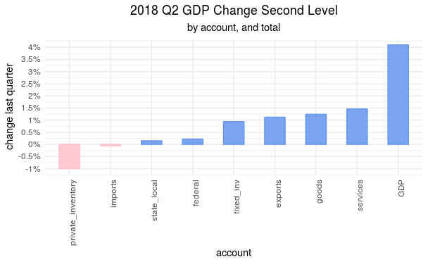

```r
gdp_second_level_components <-
  gdp_comp_change_transposed %>%
  dplyr::select(quarter,
                GDP = `Gross domestic product`,
                goods = `Goods`,
                services = `Services`,
                fixed_inv = `Fixed investment`,
                private_inventory = `Change in private inventories`,
                exports = `Exports`,
                imports = `Imports`,
                federal = `Federal`,
                state_local = `State and local`) %>%
  gather(account, quarterly_change, -quarter) %>%
  group_by(account)

gdp_second_level_components %>%
  filter(quarter == last(quarter)) %>%
   mutate(col_blue =
           if_else(quarterly_change > 0,
                  quarterly_change, as.numeric(NA)),
         col_red =
           if_else(quarterly_change < 0,
                  quarterly_change, as.numeric(NA))) %>%
  ggplot(aes(x = reorder(account, quarterly_change))) +
  geom_col(aes(y = col_red),
               alpha = .85,
               fill = "pink",
               color = "pink",
               width = .5) +
  geom_col(aes(y = col_blue),
               alpha = .85,
               fill = "cornflowerblue",
               color = "cornflowerblue",
               width = .5) +
  labs(title = paste(last(gdp_top_level_components$quarter),
                     "GDP Change Second Level",
                     sep = " "),
       subtitle = "by account, and total",
       x = "account",
       y = "change last quarter") +
  theme_minimal() +
  theme(axis.text.x = element_text(angle = 90, hjust = 1),
        plot.title = element_text(hjust = 0.5),
        plot.subtitle = element_text(hjust = 0.5)) +
  scale_y_continuous(breaks = scales::pretty_breaks(n = 10),
                     labels = function(x) paste0(x, "%"))
```

```r
gdp_second_level_hc <-
  gdp_second_level_components  %>%
  filter(quarter == (last(quarter))) %>%
  arrange(quarterly_change) %>%
  mutate(coloract = if_else(quarterly_change > 0, "#6495ed", "#ffe6ea"))

highchart() %>%
  hc_title(text = paste(last(gdp_second_level_hc$quarter),
                        "GDP Change",
                        sep = " ")) %>%
  hc_add_series(gdp_second_level_hc,
                "column",
                pointWidth = 20,
                hcaes(x = account,
                      y = quarterly_change,
                      color = coloract),
                showInLegend = FALSE) %>%
  hc_xAxis(categories = gdp_second_level_hc$account) %>%
  hc_xAxis(title = list(text = "account")) %>%
  hc_yAxis(title = list(text = "Monthly Change (percent)")) %>%
  hc_exporting(enabled = TRUE) %>%
  hc_yAxis(labels = list(format = "{value}%")) %>%
  hc_tooltip(pointFormat = "{point.y:.1f}%")
```

[interactive chart not shown]

```r
NA
```

Private inventory was down, exports, goods and services were up

### Break down to third/fourth level and confirm

Let’s take it to the next level!

```r
  gdp_comp_change_wrangled %>%
  dplyr::select(quarter,
                GDP = `Gross domestic product`,
                # Goods
                durables = `Durable goods`,
                nondurables = `Nondurable goods`,
                services = `Services`,
                # Fixed Investment
                # `Nonresidential`,
                structures = `Structures`,
                equipent = `Equipment`,
                IP = `Intellectual property products`,
                residential = `Residential`,
                private_inventory = `Change in private inventories`,
                # Exports
                export_goods = `Goods1`,
                export_services = `Services1`,
                # Imports
                import_goods = `Goods2`,
                import_services = `Services2`,
                # Federal
                defense = `National defense`,
                nondefense = `Nondefense`,
                state_local = `State and local`) %>%
  mutate(gdp_change = rowSums(select_(., -1, -2))) %>%
  dplyr::select(quarter, gdp_change, everything()) %>%
  tail()
```

| quarter | gdp_change | GDP | durables | nondurables | services | structures | equipent | IP | residential | private_inventory | export_goods | export_services | import_goods | import_services | defense | nondefense | state_local |
| --- | --- | --- | --- | --- | --- | --- | --- | --- | --- | --- | --- | --- | --- | --- | --- | --- | --- |
| 2017 Q1 | 1.79 | 1.8 | 0.13 | 0.27 | 0.82 | 0.36 | 0.50 | 0.33 | 0.41 | -0.80 | 0.33 | 0.26 | -0.57 | -0.12 | -0.01 | 0.01 | -0.13 |
| 2017 Q2 | 2.98 | 3.0 | 0.60 | 0.56 | 0.79 | 0.11 | 0.55 | 0.28 | -0.22 | 0.23 | 0.33 | 0.11 | -0.28 | -0.09 | 0.21 | -0.05 | -0.15 |
| 2017 Q3 | 2.82 | 2.8 | 0.54 | 0.32 | 0.65 | -0.18 | 0.56 | 0.08 | -0.02 | 1.04 | 0.17 | 0.25 | -0.29 | -0.12 | -0.11 | 0.03 | -0.10 |
| 2017 Q4 | 2.29 | 2.3 | 0.87 | 0.55 | 1.22 | 0.04 | 0.56 | 0.03 | 0.41 | -0.91 | 0.83 | -0.04 | -1.62 | -0.06 | 0.11 | 0.15 | 0.15 |
| 2018 Q1 | 2.22 | 2.2 | -0.15 | 0.02 | 0.49 | 0.40 | 0.49 | 0.58 | -0.14 | 0.27 | 0.26 | 0.18 | -0.30 | -0.15 | 0.11 | 0.06 | 0.10 |
| 2018 Q2 | 4.05 | 4.1 | 0.64 | 0.59 | 1.46 | 0.39 | 0.23 | 0.35 | -0.04 | -1.00 | 1.04 | 0.08 | -0.12 | 0.05 | 0.21 | 0.02 | 0.15 |

```r
gdp_third_level_components <-
  gdp_comp_change_transposed %>%
  dplyr::select(quarter,
                GDP = `Gross domestic product`,
                # Goods
                durables = `Durable goods`,
                nondurables = `Nondurable goods`,
                services = `Services`,
                # Fixed Investment
                # `Nonresidential`,
                structures = `Structures`,
                equipment = `Equipment`,
                IP = `Intellectual property products`,
                residential = `Residential`,
                private_inventory = `Change in private inventories`,
                # Exports
                export_goods = `Goods1`,
                export_services = `Services1`,
                # Imports
                import_goods = `Goods2`,
                import_services = `Services2`,
                # Federal
                defense = `National defense`,
                nondefense = `Nondefense`,
                state_local = `State and local`) %>%
  gather(account, quarterly_change, -quarter) %>%
  group_by(account)
```

```r
gdp_third_level_hc <-
  gdp_third_level_components  %>%
  filter(quarter == (last(quarter))) %>%
  arrange(quarterly_change) %>%
  mutate(coloract = if_else(quarterly_change > 0, "#6495ed", "#ffe6ea"))


highchart() %>%
  hc_title(text = paste(last(gdp_third_level_hc$quarter),
                        "GDP Change",
                        sep = " ")) %>%
  hc_subtitle(text = "by component") %>%
  hc_add_series(gdp_third_level_hc,
                "column",
                pointWidth = 20,
                hcaes(x = account,
                      y = quarterly_change,
                      color = coloract),
                showInLegend = FALSE) %>%
  hc_xAxis(categories = gdp_third_level_hc$account) %>%
  hc_xAxis(title = list(text = "account")) %>%
  hc_yAxis(title = list(text = "Monthly Change (percent)")) %>%
  hc_exporting(enabled = TRUE) %>%
  hc_yAxis(labels = list(format = "{value}%")) %>%
  hc_tooltip(pointFormat = "{point.y:.1f}%")
```

[interactive chart not shown]

```r
NA
```

We can see that exports of goods increased quite a bit, whilst exports of services didn’t. That jibes somewhat with reports that companies ‘got ahead’ of a possible tariff tit-for-tat by bringing exports forward. It’s harder to shift the timing of export of services, afterall. Okay, we confirmed that the data sum how it’s supposed to, and speaking for myself, I got a bit more familiar with GDP. There’s something about decomposing and re-wrangling data that makes it unforgettable or at least less forgettable. If someone asks what nonresidental fixed investment? it will immediately trigger the pain spent recoding this stuff - but at least I might remember the answer.

### GDP over time

```r
gdp_top_level_components %>%
  filter(quarter >= 1998) %>%
  filter(account != "GDP") %>%
  ggplot(aes(x = quarter, y = quarterly_change, color = account)) +
  geom_line() +
  scale_y_continuous(breaks = scales::pretty_breaks(n = 10),
                     labels = function(x) paste0(x, "%")) +
  labs(title = "Change in GDP components",
       y = "") +
  theme(axis.text.x = element_text(angle = 90, hjust = 1),
        plot.title = element_text(hjust = 0.5))
```

### Highcharter with tidy objects

```r
gdp_top_level_components_1980 <-
  gdp_top_level_components %>%
  filter(quarter >= 1980) %>%
  #filter(account != "GDP") %>%
  mutate(quarter = yq(quarter))
```

```r
hchart(gdp_top_level_components_1980,
       type = 'line',
       hcaes(y = quarterly_change,
             x = quarter,
             group = account)) %>%
  hc_title(text = "GDP Component Contribution to GDP") %>%
  hc_xAxis(type = 'datetime',
                 plotBands = list(
                   list(
                     label = list(text = "Bush Sr."),
                     color = "rgba(100, 0, 0, 0.1)",
                     from = datetime_to_timestamp(as.Date('1990-07-01', tz = 'UTC')),
                     to = datetime_to_timestamp(as.Date('1991-03-01', tz = 'UTC'))
                     ),
                   list(
                     label = list(text = "Dot Com"),
                     color = "rgba(100, 0, 0, 0.1)",
                     from = datetime_to_timestamp(as.Date('2001-03-01', tz = 'UTC')),
                     to = datetime_to_timestamp(as.Date('2001-11-01', tz = 'UTC'))
                     ),
                   list(
                     label = list(text = "Fin Crisis"),
                     color = "rgba(100, 0, 0, 0.1)",
                     from = datetime_to_timestamp(as.Date('2007-12-01', tz = 'UTC')),
                     to = datetime_to_timestamp(as.Date('2009-06-01', tz = 'UTC'))
                     ),
                   list(
                     label = list(text = "Volker Fed"),
                     color = "rgba(100, 0, 0, 0.1)",
                     from = datetime_to_timestamp(as.Date('1981-07-01', tz = 'UTC')),
                     to = datetime_to_timestamp(as.Date('1982-11-01', tz = 'UTC'))
                     )
                   )
               ) %>%
  hc_yAxis(labels = list(format = "{value}%")) %>%
  hc_tooltip(pointFormat = "{point.y:.1f}%") %>%
  hc_add_theme(hc_theme_flat()) %>%
  hc_navigator(enabled = FALSE) %>%
  hc_scrollbar(enabled = FALSE) %>%
  hc_legend(enabled = TRUE) %>%
  hc_exporting(enabled = TRUE)
```

[interactive chart not shown]

Massive thing to keep in mind. ‘Investment’ is not investment in the stock market. It’s Gross private domestic investment consists of purchases of fixed assets (structures, equipment, and intellectual property products) by private **businesses** … of **purchases of homes** by households, and of private business investment in inventories. (emphasis mine) Source [here](https://www.bea.gov/national/pdf/nipa_primer.pdf)